# Proyecto final

Genómica Funcional

Gómez Hernández Jorge Luis & Rojas García Luis Andrés

28 mayo, 2021

Primero se cargan todos los paquetes necesarios para este script

```r
library(dada2)
library(phyloseq)
library(Biostrings)
library(ggplot2)
library(igraph)
library(RCy3)
library(pheatmap)
```

Señalamos el directorio de trabajo donde se va a llevar todo a cabo y cargamos la librería principal que se usará.

```r
setwd("~/6 semestre/Genomica/R/genom/proyecto/") #cambiar para PROPIO directorio de trabajo
```

Ahora se define la ruta en la cual están los archivos FASTQ que se usarán

```r
ruta<-"~/6 semestre/Genomica/R/genom/proyecto/secuencias/" #debe de cambiarse segpun el usuario y su localización de sus archivos
head(list.files(ruta)) #manda los nombres de todos los archivos que hay en esa ruta
```

```
## [1] "ERR220406.fastq"             "F3D0_S188_L001_R2_001.fastq"
## [3] "filtered"                    "SRR9700829_1.fastq"
## [5] "SRR9700829_2.fastq"          "SRR9700830_1.fastq"
```

El siguiente paso es definir qué secuencias son las reverse y las forward, esto porque el experimento cuenta con secuencias pareadas. En este caso particular, los archivos con *_1* son la secuencia *forward*, mientras que los archivos con *_2* son las secuencias *reverse*.

```r
#estas líneas dividen los
forward<-sort(list.files(ruta, pattern="_1.fastq", full.names = TRUE))
reverse<-sort(list.files(ruta, pattern="_2.fastq", full.names = TRUE))
sample.names <- sapply(strsplit(basename(forward), "_"), `[`, 1) #con esta línea tenemos los nombres de las muestras sin la clasificación de forward y reverse. Separa y selecciona según la función sapply, tomamos el primer fragmento de la separación
```

# Calidad Phred

En esta parte se usará la calidad Phred para poder realizar, mas adelante, los cortes en los reads según lo que se pueda observar con las gráficas que se basan en este índice de calidad de los reads.

[output not shown]

[output not shown]

[output not shown]

[output not shown]

[output not shown]

[output not shown]

[output not shown]

[output not shown]

[output not shown]

[output not shown]

[output not shown]

[output not shown]

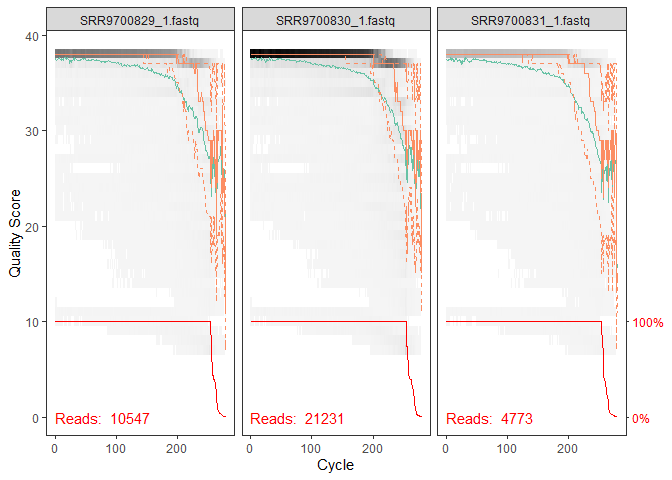

```r
#visualización de la calidad de Phred de las tres primeras secuencias tanto de forward como de reverse
plotQualityProfile(forward[1:3])
```

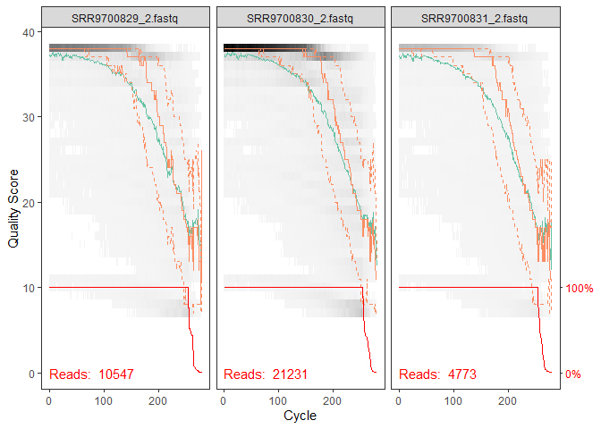

```r
plotQualityProfile(reverse[1:3])
```

# Filtrado y trimming de los reads En esta parte se hace el filtrado de los reads con los cortes arbitrarios basados con la visualización de la calidad Phred.

```r
# Colocar los archivos en un archivo llamado filtered y que contenga los forward y reverse compresos en gz
filtFs <- file.path(ruta, "filtered", paste0(sample.names, "_F_filt.fastq.gz"))
filtRs <- file.path(ruta, "filtered", paste0(sample.names, "_R_filt.fastq.gz"))
#asignamos los nombres a los archivos filtrados
names(filtFs) <- sample.names
names(filtRs) <- sample.names
```

Ahora ya sigue el corte y la formación de los archivos filtrados.

```r
#aquí se genera el archivo como tal, cada uno de los archivos "filtered" de la parte anterior ahora existe con la información obtenida aquí, ya son las secuencias filtradas con los cortes arbitrarios que se desearon.
out <- filterAndTrim(forward, filtFs, reverse, filtRs, truncLen=c(200,140),
              maxN=0, maxEE=c(2,2), truncQ=2, rm.phix=TRUE,
              compress=TRUE, multithread=F)
#se hizo el corte en las bases 200 y 140 respectivamente para poder incluir solo aquellas secuencias que sin duda son de buena calidad
head(out)
```

```
##                    reads.in reads.out
## SRR9700829_1.fastq    10547     10025
## SRR9700830_1.fastq    21231     20143
## SRR9700831_1.fastq     4773      4476
## SRR9700832_1.fastq     6713      6036
## SRR9700833_1.fastq    10500      9931
## SRR9700834_1.fastq     5363      5069
```

# Tasas de error

En esta parte se usa *machine learning* con la finalidad de poder dar el parámetro de error, se van alternando estimaciones de error inferido de la muestra y la estimación de la razón de errores hasta que convergen

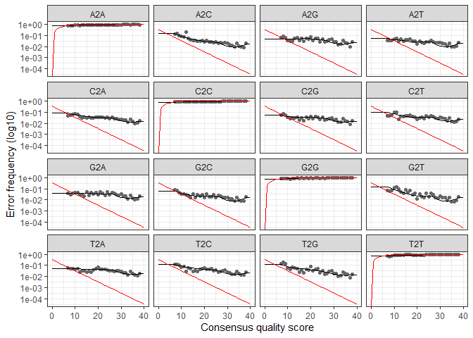

```r
#errF<-learnErrors(filtFs, multithread=TRUE)
#save(errF,file="~/R/Genomica_funcional/pro_fin_genfun/errF.RData")
#se carga el arhivo para un flujo más rápido
load("errF.RData")
#mismo proceso para los de reverse
#errR<-learnErrors(filtRs, multithread=TRUE)
#save(errR,file="~/R/Genomica_funcional/pro_fin_genfun/errR.RData")
load("errR.RData")
#esta parte los puntos son las tasas de error observadas; la línea roja es la tasa de error esperada
plotErrors(errF, nominalQ=TRUE)
```

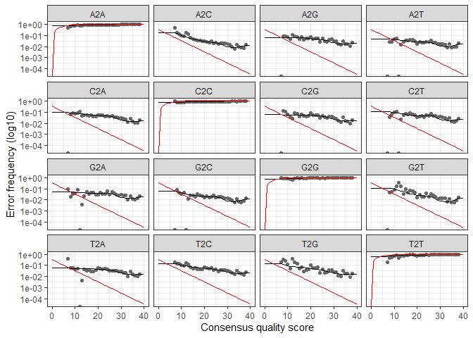

```r
plotErrors(errR, nominalQ=TRUE)
```

# Inferencia de la muestra

```r
#testa función va a remover los errores de la secuenciación, por eso es que se calculó el error previamente, anos ayudará a describir la comunidad
dadaFs <- dada(filtFs, err=errF, multithread=TRUE)
```

```
## Sample 1 - 10025 reads in 4212 unique sequences.
## Sample 2 - 20143 reads in 9833 unique sequences.
## Sample 3 - 4476 reads in 2626 unique sequences.
## Sample 4 - 6036 reads in 2307 unique sequences.
## Sample 5 - 9931 reads in 4210 unique sequences.
## Sample 6 - 5069 reads in 2500 unique sequences.
## Sample 7 - 8314 reads in 4537 unique sequences.
## Sample 8 - 5432 reads in 3033 unique sequences.
## Sample 9 - 7050 reads in 3059 unique sequences.
## Sample 10 - 5809 reads in 3190 unique sequences.
## Sample 11 - 18974 reads in 13321 unique sequences.
## Sample 12 - 6613 reads in 5146 unique sequences.
## Sample 13 - 15959 reads in 11035 unique sequences.
## Sample 14 - 16196 reads in 11239 unique sequences.
## Sample 15 - 18491 reads in 12420 unique sequences.
## Sample 16 - 10901 reads in 7933 unique sequences.
## Sample 17 - 26575 reads in 17001 unique sequences.
## Sample 18 - 5503 reads in 4227 unique sequences.
## Sample 19 - 10749 reads in 7197 unique sequences.
## Sample 20 - 17254 reads in 10995 unique sequences.
## Sample 21 - 26402 reads in 11222 unique sequences.
## Sample 22 - 21765 reads in 9274 unique sequences.
## Sample 23 - 16274 reads in 7033 unique sequences.
## Sample 24 - 8964 reads in 4666 unique sequences.
## Sample 25 - 18546 reads in 8765 unique sequences.
## Sample 26 - 24764 reads in 11019 unique sequences.
## Sample 27 - 32156 reads in 12708 unique sequences.
## Sample 28 - 22124 reads in 9512 unique sequences.
## Sample 29 - 26409 reads in 11097 unique sequences.
## Sample 30 - 16045 reads in 7610 unique sequences.
## Sample 31 - 2472 reads in 1404 unique sequences.
## Sample 32 - 11116 reads in 3893 unique sequences.
## Sample 33 - 4727 reads in 2433 unique sequences.
## Sample 34 - 15703 reads in 7490 unique sequences.
## Sample 35 - 7556 reads in 3918 unique sequences.
## Sample 36 - 14638 reads in 7344 unique sequences.
## Sample 37 - 110 reads in 106 unique sequences.
## Sample 38 - 6462 reads in 3331 unique sequences.
## Sample 39 - 14058 reads in 6072 unique sequences.
## Sample 40 - 2551 reads in 1389 unique sequences.
```

[output cut: 139 more lines]

```
## Sample 180 - 12707 reads in 8821 unique sequences.
## Sample 181 - 12058 reads in 8689 unique sequences.
## Sample 182 - 15325 reads in 10697 unique sequences.
## Sample 183 - 9626 reads in 7086 unique sequences.
## Sample 184 - 14160 reads in 6396 unique sequences.
## Sample 185 - 21366 reads in 9190 unique sequences.
## Sample 186 - 18226 reads in 11467 unique sequences.
## Sample 187 - 11550 reads in 5675 unique sequences.
## Sample 188 - 13477 reads in 6765 unique sequences.
## Sample 189 - 18205 reads in 7728 unique sequences.
## Sample 190 - 21556 reads in 10170 unique sequences.
## Sample 191 - 22024 reads in 9912 unique sequences.
## Sample 192 - 17582 reads in 7860 unique sequences.
## Sample 193 - 19052 reads in 8706 unique sequences.
## Sample 194 - 18439 reads in 8074 unique sequences.
```

```r
#save(dadaFs,file="~/R/Genomica_funcional/pro_fin_genfun/dadaFs.RData")
#se guaradó y cargó el objeto para agilizar el proceso
#load("dadaFs.RData")
dadaRs <- dada(filtRs, err=errR, multithread=TRUE)
```

```
## Sample 1 - 10025 reads in 3608 unique sequences.
## Sample 2 - 20143 reads in 8538 unique sequences.
## Sample 3 - 4476 reads in 2343 unique sequences.
## Sample 4 - 6036 reads in 1971 unique sequences.
## Sample 5 - 9931 reads in 3595 unique sequences.
## Sample 6 - 5069 reads in 2175 unique sequences.
## Sample 7 - 8314 reads in 4017 unique sequences.
## Sample 8 - 5432 reads in 2683 unique sequences.
## Sample 9 - 7050 reads in 2623 unique sequences.
## Sample 10 - 5809 reads in 2805 unique sequences.
## Sample 11 - 18974 reads in 12114 unique sequences.
## Sample 12 - 6613 reads in 4740 unique sequences.
## Sample 13 - 15959 reads in 9985 unique sequences.
## Sample 14 - 16196 reads in 10057 unique sequences.
## Sample 15 - 18491 reads in 11194 unique sequences.
## Sample 16 - 10901 reads in 7251 unique sequences.
## Sample 17 - 26575 reads in 14888 unique sequences.
## Sample 18 - 5503 reads in 3927 unique sequences.
## Sample 19 - 10749 reads in 6587 unique sequences.
## Sample 20 - 17254 reads in 10046 unique sequences.
## Sample 21 - 26402 reads in 9735 unique sequences.
## Sample 22 - 21765 reads in 7970 unique sequences.
## Sample 23 - 16274 reads in 6317 unique sequences.
## Sample 24 - 8964 reads in 4183 unique sequences.
## Sample 25 - 18546 reads in 7700 unique sequences.
## Sample 26 - 24764 reads in 9602 unique sequences.
## Sample 27 - 32156 reads in 10811 unique sequences.
## Sample 28 - 22124 reads in 8371 unique sequences.
## Sample 29 - 26409 reads in 9578 unique sequences.
## Sample 30 - 16045 reads in 6638 unique sequences.
## Sample 31 - 2472 reads in 1253 unique sequences.
## Sample 32 - 11116 reads in 3465 unique sequences.
## Sample 33 - 4727 reads in 2199 unique sequences.
## Sample 34 - 15703 reads in 6583 unique sequences.
## Sample 35 - 7556 reads in 3414 unique sequences.
## Sample 36 - 14638 reads in 6255 unique sequences.
## Sample 37 - 110 reads in 106 unique sequences.
## Sample 38 - 6462 reads in 2922 unique sequences.
## Sample 39 - 14058 reads in 5361 unique sequences.
## Sample 40 - 2551 reads in 1153 unique sequences.
```

[output cut: 139 more lines]

```
## Sample 180 - 12707 reads in 7966 unique sequences.
## Sample 181 - 12058 reads in 7973 unique sequences.
## Sample 182 - 15325 reads in 9600 unique sequences.
## Sample 183 - 9626 reads in 6618 unique sequences.
## Sample 184 - 14160 reads in 5558 unique sequences.
## Sample 185 - 21366 reads in 8075 unique sequences.
## Sample 186 - 18226 reads in 10493 unique sequences.
## Sample 187 - 11550 reads in 4889 unique sequences.
## Sample 188 - 13477 reads in 5899 unique sequences.
## Sample 189 - 18205 reads in 6642 unique sequences.
## Sample 190 - 21556 reads in 8778 unique sequences.
## Sample 191 - 22024 reads in 8826 unique sequences.
## Sample 192 - 17582 reads in 6689 unique sequences.
## Sample 193 - 19052 reads in 7570 unique sequences.
## Sample 194 - 18439 reads in 6945 unique sequences.
```

```r
#save(dadaRs,file="~/R/Genomica_funcional/pro_fin_genfun/dadaRs.RData")
#mismo proceso que con el objeto anterior
#load("dadaRs.RData")
```

# Unir las secuencias *paired reads*

En esta sección unimos las secuencias *forward* y las *reverse* de las muestras obtenidas.

```r
mergers <- mergePairs(dadaFs, filtFs, dadaRs, filtRs, verbose=TRUE)
```

```
## 8912 paired-reads (in 160 unique pairings) successfully merged out of 9078 (in 203 pairings) input.
```

```
## 16153 paired-reads (in 404 unique pairings) successfully merged out of 17625 (in 618 pairings) input.
```

```
## 3282 paired-reads (in 139 unique pairings) successfully merged out of 3502 (in 197 pairings) input.
```

```
## 5427 paired-reads (in 112 unique pairings) successfully merged out of 5510 (in 135 pairings) input.
```

```
## 8745 paired-reads (in 126 unique pairings) successfully merged out of 9083 (in 188 pairings) input.
```

```
## 4306 paired-reads (in 110 unique pairings) successfully merged out of 4456 (in 155 pairings) input.
```

```
## 6329 paired-reads (in 236 unique pairings) successfully merged out of 6841 (in 340 pairings) input.
```

```
## 4197 paired-reads (in 150 unique pairings) successfully merged out of 4440 (in 201 pairings) input.
```

```
## 6011 paired-reads (in 167 unique pairings) successfully merged out of 6276 (in 228 pairings) input.
```

```
## 4567 paired-reads (in 156 unique pairings) successfully merged out of 4795 (in 204 pairings) input.
```

```
## 9974 paired-reads (in 408 unique pairings) successfully merged out of 14925 (in 1771 pairings) input.
```

```
## 2920 paired-reads (in 150 unique pairings) successfully merged out of 4604 (in 522 pairings) input.
```

```
## 8931 paired-reads (in 393 unique pairings) successfully merged out of 12824 (in 1412 pairings) input.
```

```
## 8809 paired-reads (in 396 unique pairings) successfully merged out of 12914 (in 1479 pairings) input.
```

```
## 10078 paired-reads (in 451 unique pairings) successfully merged out of 14611 (in 1585 pairings) input.
```

```
## 5370 paired-reads (in 281 unique pairings) successfully merged out of 7937 (in 915 pairings) input.
```

```
## 15948 paired-reads (in 592 unique pairings) successfully merged out of 22105 (in 2185 pairings) input.
```

```
## 2612 paired-reads (in 158 unique pairings) successfully merged out of 3755 (in 439 pairings) input.
```

```
## 6094 paired-reads (in 266 unique pairings) successfully merged out of 8549 (in 931 pairings) input.
```

```
## 10580 paired-reads (in 429 unique pairings) successfully merged out of 14206 (in 1537 pairings) input.
```

```
## 22611 paired-reads (in 467 unique pairings) successfully merged out of 23948 (in 691 pairings) input.
```

```
## 18283 paired-reads (in 436 unique pairings) successfully merged out of 19701 (in 665 pairings) input.
```

```
## 13485 paired-reads (in 377 unique pairings) successfully merged out of 14284 (in 543 pairings) input.
```

```
## 7341 paired-reads (in 240 unique pairings) successfully merged out of 7728 (in 334 pairings) input.
```

```
## 15169 paired-reads (in 394 unique pairings) successfully merged out of 16333 (in 597 pairings) input.
```

```
## 20774 paired-reads (in 514 unique pairings) successfully merged out of 22283 (in 772 pairings) input.
```

```
## 27708 paired-reads (in 459 unique pairings) successfully merged out of 29248 (in 660 pairings) input.
```

```
## 18359 paired-reads (in 388 unique pairings) successfully merged out of 19784 (in 575 pairings) input.
```

```
## 22227 paired-reads (in 460 unique pairings) successfully merged out of 23852 (in 708 pairings) input.
```

```
## 11998 paired-reads (in 350 unique pairings) successfully merged out of 13837 (in 518 pairings) input.
```

```
## 1902 paired-reads (in 71 unique pairings) successfully merged out of 1975 (in 87 pairings) input.
```

```
## 9861 paired-reads (in 164 unique pairings) successfully merged out of 10205 (in 233 pairings) input.
```

```
## 3833 paired-reads (in 147 unique pairings) successfully merged out of 4008 (in 188 pairings) input.
```

```
## 13082 paired-reads (in 364 unique pairings) successfully merged out of 13678 (in 515 pairings) input.
```

```
## 5787 paired-reads (in 202 unique pairings) successfully merged out of 6180 (in 290 pairings) input.
```

```
## 11880 paired-reads (in 325 unique pairings) successfully merged out of 12682 (in 481 pairings) input.
```

```
## 5 paired-reads (in 2 unique pairings) successfully merged out of 5 (in 2 pairings) input.
```

```
## 5228 paired-reads (in 193 unique pairings) successfully merged out of 5510 (in 250 pairings) input.
```

```
## 12263 paired-reads (in 289 unique pairings) successfully merged out of 12613 (in 379 pairings) input.
```

```
## 1826 paired-reads (in 71 unique pairings) successfully merged out of 1941 (in 91 pairings) input.
```

```
## 9803 paired-reads (in 378 unique pairings) successfully merged out of 14110 (in 1481 pairings) input.
```

```
## 12651 paired-reads (in 484 unique pairings) successfully merged out of 17869 (in 1826 pairings) input.
```

```
## 14441 paired-reads (in 544 unique pairings) successfully merged out of 19857 (in 2075 pairings) input.
```

```
## 5853 paired-reads (in 262 unique pairings) successfully merged out of 8756 (in 979 pairings) input.
```

```
## 12109 paired-reads (in 471 unique pairings) successfully merged out of 17174 (in 1814 pairings) input.
```

```
## 5945 paired-reads (in 283 unique pairings) successfully merged out of 8976 (in 1025 pairings) input.
```

```
## 4963 paired-reads (in 215 unique pairings) successfully merged out of 7274 (in 747 pairings) input.
```

```
## 4275 paired-reads (in 189 unique pairings) successfully merged out of 6598 (in 679 pairings) input.
```

```
## 2200 paired-reads (in 110 unique pairings) successfully merged out of 3065 (in 307 pairings) input.
```

```
## 14608 paired-reads (in 570 unique pairings) successfully merged out of 19614 (in 1852 pairings) input.
```

```
## 13595 paired-reads (in 386 unique pairings) successfully merged out of 14591 (in 544 pairings) input.
```

```
## 3538 paired-reads (in 144 unique pairings) successfully merged out of 3716 (in 196 pairings) input.
```

```
## 10304 paired-reads (in 331 unique pairings) successfully merged out of 11251 (in 462 pairings) input.
```

```
## 4233 paired-reads (in 168 unique pairings) successfully merged out of 4516 (in 232 pairings) input.
```

```
## 10055 paired-reads (in 298 unique pairings) successfully merged out of 10880 (in 443 pairings) input.
```

```
## 20134 paired-reads (in 439 unique pairings) successfully merged out of 21240 (in 655 pairings) input.
```

```
## 9538 paired-reads (in 287 unique pairings) successfully merged out of 10064 (in 397 pairings) input.
```

```
## 25956 paired-reads (in 560 unique pairings) successfully merged out of 27732 (in 861 pairings) input.
```

```
## 564 paired-reads (in 41 unique pairings) successfully merged out of 925 (in 105 pairings) input.
```

```
## 5044 paired-reads (in 221 unique pairings) successfully merged out of 5986 (in 319 pairings) input.
```

```
## 19516 paired-reads (in 383 unique pairings) successfully merged out of 20823 (in 565 pairings) input.
```

```
## 2936 paired-reads (in 143 unique pairings) successfully merged out of 4199 (in 485 pairings) input.
```

```
## 5795 paired-reads (in 142 unique pairings) successfully merged out of 6104 (in 195 pairings) input.
```

```
## 10523 paired-reads (in 296 unique pairings) successfully merged out of 11105 (in 389 pairings) input.
```

```
## 19311 paired-reads (in 414 unique pairings) successfully merged out of 20367 (in 619 pairings) input.
```

```
## 13448 paired-reads (in 285 unique pairings) successfully merged out of 14047 (in 417 pairings) input.
```

```
## 6938 paired-reads (in 248 unique pairings) successfully merged out of 7254 (in 338 pairings) input.
```

```
## 6047 paired-reads (in 229 unique pairings) successfully merged out of 6386 (in 313 pairings) input.
```

```
## 8170 paired-reads (in 155 unique pairings) successfully merged out of 8362 (in 209 pairings) input.
```

```
## 7918 paired-reads (in 272 unique pairings) successfully merged out of 8581 (in 402 pairings) input.
```

```
## 3985 paired-reads (in 191 unique pairings) successfully merged out of 5596 (in 580 pairings) input.
```

```
## 7690 paired-reads (in 233 unique pairings) successfully merged out of 8016 (in 326 pairings) input.
```

```
## 10773 paired-reads (in 179 unique pairings) successfully merged out of 11042 (in 250 pairings) input.
```

```
## 3848 paired-reads (in 181 unique pairings) successfully merged out of 5973 (in 644 pairings) input.
```

```
## 2028 paired-reads (in 103 unique pairings) successfully merged out of 3024 (in 313 pairings) input.
```

```
## 3413 paired-reads (in 157 unique pairings) successfully merged out of 5336 (in 569 pairings) input.
```

```
## 593 paired-reads (in 37 unique pairings) successfully merged out of 942 (in 113 pairings) input.
```

```
## 11703 paired-reads (in 339 unique pairings) successfully merged out of 14496 (in 1069 pairings) input.
```

```
## 1851 paired-reads (in 85 unique pairings) successfully merged out of 2485 (in 226 pairings) input.
```

```
## 50 paired-reads (in 7 unique pairings) successfully merged out of 73 (in 10 pairings) input.
```

```
## 3027 paired-reads (in 134 unique pairings) successfully merged out of 4118 (in 397 pairings) input.
```

```
## 6645 paired-reads (in 284 unique pairings) successfully merged out of 10323 (in 1052 pairings) input.
```

```
## 5516 paired-reads (in 238 unique pairings) successfully merged out of 8633 (in 870 pairings) input.
```

```
## 1 paired-reads (in 1 unique pairings) successfully merged out of 1 (in 1 pairings) input.
```

```
## 12590 paired-reads (in 301 unique pairings) successfully merged out of 13784 (in 463 pairings) input.
```

```
## 4546 paired-reads (in 177 unique pairings) successfully merged out of 4816 (in 242 pairings) input.
```

```
## 9237 paired-reads (in 271 unique pairings) successfully merged out of 10293 (in 451 pairings) input.
```

```
## 12656 paired-reads (in 334 unique pairings) successfully merged out of 13240 (in 477 pairings) input.
```

```
## 12830 paired-reads (in 329 unique pairings) successfully merged out of 14130 (in 497 pairings) input.
```

```
## 11040 paired-reads (in 299 unique pairings) successfully merged out of 11644 (in 417 pairings) input.
```

```
## 2683 paired-reads (in 129 unique pairings) successfully merged out of 2854 (in 165 pairings) input.
```

```
## 14880 paired-reads (in 243 unique pairings) successfully merged out of 15582 (in 359 pairings) input.
```

```
## 14018 paired-reads (in 202 unique pairings) successfully merged out of 14774 (in 289 pairings) input.
```

```
## 8949 paired-reads (in 286 unique pairings) successfully merged out of 9828 (in 430 pairings) input.
```

```
## 71 paired-reads (in 16 unique pairings) successfully merged out of 86 (in 18 pairings) input.
```

```
## 16446 paired-reads (in 348 unique pairings) successfully merged out of 17385 (in 513 pairings) input.
```

```
## 5088 paired-reads (in 159 unique pairings) successfully merged out of 5448 (in 208 pairings) input.
```

```
## 6276 paired-reads (in 249 unique pairings) successfully merged out of 10637 (in 1218 pairings) input.
```

```
## 2946 paired-reads (in 157 unique pairings) successfully merged out of 5536 (in 591 pairings) input.
```

```
## 14664 paired-reads (in 449 unique pairings) successfully merged out of 18044 (in 1529 pairings) input.
```

```
## 10585 paired-reads (in 359 unique pairings) successfully merged out of 13587 (in 1311 pairings) input.
```

```
## 8760 paired-reads (in 318 unique pairings) successfully merged out of 11066 (in 969 pairings) input.
```

```
## No paired-reads (in ZERO unique pairings) successfully merged out of 17 pairings) input.
```

```
## 4643 paired-reads (in 199 unique pairings) successfully merged out of 7404 (in 821 pairings) input.
```

```
## 9287 paired-reads (in 388 unique pairings) successfully merged out of 13483 (in 1388 pairings) input.
```

```
## 3879 paired-reads (in 183 unique pairings) successfully merged out of 6164 (in 583 pairings) input.
```

```
## 2768 paired-reads (in 151 unique pairings) successfully merged out of 4065 (in 421 pairings) input.
```

```
## 9545 paired-reads (in 240 unique pairings) successfully merged out of 10123 (in 345 pairings) input.
```

```
## 33909 paired-reads (in 319 unique pairings) successfully merged out of 34628 (in 451 pairings) input.
```

```
## 9232 paired-reads (in 177 unique pairings) successfully merged out of 9653 (in 259 pairings) input.
```

```
## 9746 paired-reads (in 159 unique pairings) successfully merged out of 10307 (in 247 pairings) input.
```

```
## 13930 paired-reads (in 212 unique pairings) successfully merged out of 14451 (in 293 pairings) input.
```

```
## 14609 paired-reads (in 371 unique pairings) successfully merged out of 15484 (in 531 pairings) input.
```

```
## 8463 paired-reads (in 288 unique pairings) successfully merged out of 9110 (in 418 pairings) input.
```

```
## 12777 paired-reads (in 370 unique pairings) successfully merged out of 13730 (in 527 pairings) input.
```

```
## 8293 paired-reads (in 296 unique pairings) successfully merged out of 8908 (in 429 pairings) input.
```

```
## 15261 paired-reads (in 431 unique pairings) successfully merged out of 16171 (in 612 pairings) input.
```

```
## No paired-reads (in ZERO unique pairings) successfully merged out of 10 pairings) input.
```

```
## 27 paired-reads (in 4 unique pairings) successfully merged out of 38 (in 8 pairings) input.
```

```
## 9098 paired-reads (in 293 unique pairings) successfully merged out of 11677 (in 974 pairings) input.
```

```
## 1339 paired-reads (in 66 unique pairings) successfully merged out of 1920 (in 177 pairings) input.
```

```
## 2176 paired-reads (in 127 unique pairings) successfully merged out of 4102 (in 446 pairings) input.
```

```
## 1380 paired-reads (in 85 unique pairings) successfully merged out of 2261 (in 240 pairings) input.
```

```
## 1304 paired-reads (in 83 unique pairings) successfully merged out of 2206 (in 251 pairings) input.
```

```
## 8450 paired-reads (in 395 unique pairings) successfully merged out of 12345 (in 1426 pairings) input.
```

```
## 1160 paired-reads (in 74 unique pairings) successfully merged out of 1993 (in 225 pairings) input.
```

```
## 538 paired-reads (in 37 unique pairings) successfully merged out of 840 (in 84 pairings) input.
```

```
## 1783 paired-reads (in 102 unique pairings) successfully merged out of 2453 (in 250 pairings) input.
```

```
## 4672 paired-reads (in 216 unique pairings) successfully merged out of 7080 (in 791 pairings) input.
```

```
## 3822 paired-reads (in 191 unique pairings) successfully merged out of 6186 (in 685 pairings) input.
```

```
## 3331 paired-reads (in 168 unique pairings) successfully merged out of 5469 (in 641 pairings) input.
```

```
## 6 paired-reads (in 1 unique pairings) successfully merged out of 6 (in 1 pairings) input.
```

```
## 4632 paired-reads (in 213 unique pairings) successfully merged out of 7397 (in 780 pairings) input.
```

```
## 5696 paired-reads (in 237 unique pairings) successfully merged out of 7755 (in 743 pairings) input.
```

```
## 3564 paired-reads (in 138 unique pairings) successfully merged out of 4879 (in 445 pairings) input.
```

```
## 4131 paired-reads (in 209 unique pairings) successfully merged out of 7363 (in 838 pairings) input.
```

```
## 6279 paired-reads (in 287 unique pairings) successfully merged out of 10253 (in 1174 pairings) input.
```

```
## 6478 paired-reads (in 272 unique pairings) successfully merged out of 9281 (in 989 pairings) input.
```

```
## 3110 paired-reads (in 142 unique pairings) successfully merged out of 4745 (in 571 pairings) input.
```

```
## 17752 paired-reads (in 435 unique pairings) successfully merged out of 19500 (in 651 pairings) input.
```

```
## No paired-reads (in ZERO unique pairings) successfully merged out of 5 pairings) input.
```

```
## 3997 paired-reads (in 186 unique pairings) successfully merged out of 6592 (in 731 pairings) input.
```

```
## 7948 paired-reads (in 338 unique pairings) successfully merged out of 11986 (in 1483 pairings) input.
```

```
## 6236 paired-reads (in 240 unique pairings) successfully merged out of 9007 (in 1061 pairings) input.
```

```
## 12686 paired-reads (in 471 unique pairings) successfully merged out of 17267 (in 1832 pairings) input.
```

```
## 2480 paired-reads (in 128 unique pairings) successfully merged out of 2727 (in 175 pairings) input.
```

```
## 4454 paired-reads (in 194 unique pairings) successfully merged out of 4773 (in 260 pairings) input.
```

```
## 5193 paired-reads (in 211 unique pairings) successfully merged out of 8145 (in 904 pairings) input.
```

```
## 1136 paired-reads (in 67 unique pairings) successfully merged out of 1822 (in 195 pairings) input.
```

```
## No paired-reads (in ZERO unique pairings) successfully merged out of 18 pairings) input.
```

```
## 5171 paired-reads (in 221 unique pairings) successfully merged out of 8026 (in 841 pairings) input.
```

```
## 3173 paired-reads (in 153 unique pairings) successfully merged out of 5191 (in 560 pairings) input.
```

```
## 7694 paired-reads (in 316 unique pairings) successfully merged out of 11654 (in 1194 pairings) input.
```

```
## 874 paired-reads (in 57 unique pairings) successfully merged out of 1505 (in 159 pairings) input.
```

```
## 11626 paired-reads (in 503 unique pairings) successfully merged out of 19043 (in 2143 pairings) input.
```

```
## 12735 paired-reads (in 415 unique pairings) successfully merged out of 16023 (in 1320 pairings) input.
```

```
## 5 paired-reads (in 1 unique pairings) successfully merged out of 5 (in 1 pairings) input.
```

```
## 12240 paired-reads (in 440 unique pairings) successfully merged out of 17111 (in 1770 pairings) input.
```

```
## 8558 paired-reads (in 326 unique pairings) successfully merged out of 12047 (in 1264 pairings) input.
```

```
## 5430 paired-reads (in 253 unique pairings) successfully merged out of 8187 (in 860 pairings) input.
```

```
## 3898 paired-reads (in 186 unique pairings) successfully merged out of 5603 (in 594 pairings) input.
```

```
## 10492 paired-reads (in 433 unique pairings) successfully merged out of 15120 (in 1757 pairings) input.
```

```
## 3860 paired-reads (in 184 unique pairings) successfully merged out of 5556 (in 673 pairings) input.
```

```
## 25406 paired-reads (in 511 unique pairings) successfully merged out of 26849 (in 771 pairings) input.
```

```
## 19965 paired-reads (in 448 unique pairings) successfully merged out of 20962 (in 650 pairings) input.
```

```
## 25328 paired-reads (in 546 unique pairings) successfully merged out of 26752 (in 818 pairings) input.
```

```
## 11275 paired-reads (in 288 unique pairings) successfully merged out of 12386 (in 433 pairings) input.
```

```
## 38754 paired-reads (in 494 unique pairings) successfully merged out of 40948 (in 778 pairings) input.
```

```
## 8713 paired-reads (in 299 unique pairings) successfully merged out of 9539 (in 454 pairings) input.
```

```
## 8453 paired-reads (in 250 unique pairings) successfully merged out of 9035 (in 355 pairings) input.
```

```
## 1916 paired-reads (in 105 unique pairings) successfully merged out of 2304 (in 155 pairings) input.
```

```
## 2813 paired-reads (in 139 unique pairings) successfully merged out of 3099 (in 196 pairings) input.
```

```
## 9619 paired-reads (in 299 unique pairings) successfully merged out of 10540 (in 416 pairings) input.
```

```
## 6708 paired-reads (in 291 unique pairings) successfully merged out of 9496 (in 1028 pairings) input.
```

```
## 9448 paired-reads (in 427 unique pairings) successfully merged out of 13725 (in 1603 pairings) input.
```

```
## 2397 paired-reads (in 131 unique pairings) successfully merged out of 3687 (in 419 pairings) input.
```

```
## 8889 paired-reads (in 379 unique pairings) successfully merged out of 12722 (in 1420 pairings) input.
```

```
## 12899 paired-reads (in 528 unique pairings) successfully merged out of 18227 (in 2197 pairings) input.
```

```
## 7421 paired-reads (in 341 unique pairings) successfully merged out of 10890 (in 1328 pairings) input.
```

```
## 7003 paired-reads (in 311 unique pairings) successfully merged out of 9978 (in 1069 pairings) input.
```

```
## 5737 paired-reads (in 262 unique pairings) successfully merged out of 9059 (in 1075 pairings) input.
```

```
## 8212 paired-reads (in 341 unique pairings) successfully merged out of 11849 (in 1244 pairings) input.
```

```
## 4530 paired-reads (in 206 unique pairings) successfully merged out of 6898 (in 801 pairings) input.
```

```
## 11249 paired-reads (in 327 unique pairings) successfully merged out of 12382 (in 483 pairings) input.
```

```
## 17964 paired-reads (in 431 unique pairings) successfully merged out of 19004 (in 669 pairings) input.
```

```
## 11140 paired-reads (in 442 unique pairings) successfully merged out of 15179 (in 1701 pairings) input.
```

```
## 8702 paired-reads (in 293 unique pairings) successfully merged out of 9995 (in 429 pairings) input.
```

```
## 10921 paired-reads (in 292 unique pairings) successfully merged out of 11550 (in 413 pairings) input.
```

```
## 15663 paired-reads (in 327 unique pairings) successfully merged out of 16276 (in 455 pairings) input.
```

```
## 18134 paired-reads (in 468 unique pairings) successfully merged out of 19099 (in 661 pairings) input.
```

```
## 18361 paired-reads (in 486 unique pairings) successfully merged out of 19949 (in 738 pairings) input.
```

```
## 14830 paired-reads (in 319 unique pairings) successfully merged out of 15759 (in 489 pairings) input.
```

```
## 14428 paired-reads (in 383 unique pairings) successfully merged out of 16541 (in 562 pairings) input.
```

```
## 15834 paired-reads (in 353 unique pairings) successfully merged out of 16626 (in 514 pairings) input.
```

```r
head(mergers[[1]])
```

```
##                                                                                                                                                                                                                                                                                                          …
## 1                                                                                AAGTCGTAACAAGGTTTCCGTAGGTGAACCTGCGGAAGGATCATTCACAAACGAGTGTTT…
## 2                                                                                GAGAGCCAAGAGATCCGTTGTTGAAAGTTATATTTTGAATTAAGTATATTCATAATATGT…
## 3                                                  AAGTCGTAACAAGGTTTCCGTAGGTGAACCTGCGGAAGGATCATTATCGAATCGTAGGCG…
## 4                                                  GAGAGCCAAGAGATCCGTTGTTGAAAGTTGTATAGTTTTCTTTCGTTACGTTTTCAAGGC…
## 5                                                                               GAGAGCCAAGAGATCCGTTGTTAAAAGTTGTATTTCGAATTATGTATTCAAAAAATTTCA…
## 6 CGGAACCAAGAGATCCATTGTTGAAAGTTTTGACTGATCAATTTCTCACATCATTCCCAC…
##   abundance forward reverse nmatch nmismatch nindel prefer accept
## 1       851       1       1    109         0      0      2   TRUE
## 2       815       2       2    109         0      0      2   TRUE
## 3       640       3       4     79         0      0      2   TRUE
## 4       622       4       3     79         0      0      2   TRUE
## 5       514       5       5    108         0      0      2   TRUE
## 6       456       6       6     30         0      0      2   TRUE
```